# IPF_paper_figure1

2023-09-25

# 1 general settings

```r
library(magrittr)
library(ComplexHeatmap)
library(ggplot2)

working.dir = "/home/jyu/rstudio/"

ms_dir = paste0(working.dir,"/IPF_manuscript/manuscriptV3/figures")
ms_date = "20230921"
```

## 1.1 color

```r
stage_color = c("Control" = "grey",
                "Early-IPF" = "#076B94",
                "Advanced-IPF" = "#C6A775")
```

# 2 20221017 clustering analysis of pulmonary function parameters

```r
input = readxl::read_xlsx(path = paste0(working.dir,"/IPF_manuscript/meta_data/prevalent_all_incident.xlsx"),sheet = "Sheet1")

input$medication_group = ifelse(input$medication == "no", "no", "yes")

# only focus on IPF patients and controls
input = input[input$Dx %in% c("IPF","Control"),]

input$genderNum = ifelse(input$Gender == "female", 0, 1)
input$smokingNum = ifelse(input$smoking == "nd",0,
                                ifelse(input$smoking == "ex",1,
                                       ifelse(input$smoking == "yes",2,3)))

input=input[!is.na(input$identifier),]

rownames(input) = input$identifier
library(Amelia)
# remove prevalent 2 patients which have no data for lung function parameters
input = input[!rownames(input) %in% c("IPF4","IPF2718174"),]
input[input=="nd"] = NA

## integrate FVC and VC information
input$FVCorVC_percent = ifelse(is.na(input$FVC_percent),input$VC_percent,input$FVC_percent)
```

## 2.1 select lung function para

```r
# input$FVCorVC_percent = ifelse(is.na(input$FVC_percent),input$VC_percent,input$FVC_percent)
# # cols.num <- c("Age","FVCorVC_percent","FEV1_percent","TLC_percent","DLCO_percent","pO2","pCO2")
# cols.num <- c("FVCorVC_percent","FEV1_percent","TLC_percent","DLCO_percent","pO2","pCO2")
#
# # test = subset(input,cohort=="prevalent")
# test = input[,cols.num]
# test <- sapply(test,as.numeric)
#
#
# # library("PerformanceAnalytics")
# # chart.Correlation(test, histogram=TRUE, pch=19)
#
# rm(test)
```

### 2.1.1 impute data

```r
# cols.num <- c("Age","FVCorVC_percent","FEV1_percent","TLC_percent","DLCO_percent","pO2","pCO2")
#
#
# test = input[,cols.num]
# test <- sapply(test,as.numeric)
# rownames(test) = input$identifier
# # rownames(test) = paste0("group",tmp_data$group,"_",rownames(tmp_data))
# impute_data = amelia(as.data.frame(test),m = 5,parallel = "multicore")
# impute_cluster = dist(scale(impute_data$imputations$imp5)) %>% hclust()
# # write.csv(impute_data$imputations$imp1,file = paste0(working.dir,"/clinical_phenotype/20221205_imputed_data_7parameters.csv"))
# rm(test)
```

### 2.1.2 clustering

```r
impute_data = read.csv(file = paste0(working.dir,"/IPF_manuscript/meta_data/20221205_imputed_data_7parameters.csv"),row.names = 1)
cols.num <- c("FVCorVC_percent","FEV1_percent","TLC_percent","DLCO_percent","pO2","pCO2")

impute_data = impute_data[,cols.num]

impute_cluster = dist(scale(impute_data)) %>% hclust()

# plot(impute_cluster)
#
p = ComplexHeatmap::Heatmap(scale(impute_data),
                            clustering_distance_rows = "euclidean",
                            clustering_distance_columns = "euclidean")

# p
```

### 2.1.3 save cluster information

it contains scaled values for all parameters

```r
p_matrix = p@matrix

p_order = ComplexHeatmap::row_order(p)
test = p_matrix[p_order,]

# write.csv(test,file = paste0(working.dir,"/20230605_scaledvalue_patient_stages.csv"))

rm(test,p,p_order,p_matrix,impute_cluster,impute_data,cols.num)
```

# 3 Figure S1

## 3.1 Figure S1A

```r
cols.num <- c("Age","Opacity","OpacityScore","AvgGroundglass","AvgReticular","AvgnormalLung","VC","VC_percent","FEV1","FEV1_percent","TLC_percent","TLC","DLCO_percent","pO2","pCO2")

cols.num.anno = c("Age","Opacity","Opacity Score","Ground glass","Reticular","NormalLung","VC","VC predicted","FEV1","FEV1 predicted","TLC predicted","TLC","DLCO predicted","pO2","pCO2")

test = subset(input,cohort=="prevalent")
# test = input
test = test[,cols.num]

colnames(test) = cols.num.anno

test <- sapply(test,as.numeric)

# BiocManager::install("PerformanceAnalytics")

# library("PerformanceAnalytics")
# chart.Correlation(test,
#                   histogram=TRUE,
#                   method = "pearson",
#                   pch=16)
#
cor_test_mat <- psych::corr.test(cor(test,use = "complete.obs"))$p    # Apply corr.test function
# cor_test_mat

pdf(file = paste0(ms_dir,"/figs1a.para.correlation_",ms_date,".pdf"),width = 6,height = 6)
p = cor(test,use = "complete.obs") %>%
  corrplot::corrplot(.,
                     type="upper",
                     order="original",
                     bg = "#00000000",
                     col=colorRampPalette(c("blue","white","red"))(200),
                     p.mat = cor_test_mat,
                     sig.level = c(0.001, 0.01, 0.05),
                     pch.cex = 0.9,
                     insig = 'label_sig',
                     pch.col = 'grey20',
                     # col = c("lightblue","white","red"),
                     tl.col="black",
                     tl.srt=90,
                     cl.pos = "b",
                     cl.ratio=0.2
                     )

print(p)
```

[output not shown]

[output cut: 137 more lines]

[output not shown]

```r
# plot(c(1,1))
text(x=2,y=2,"Pearson correlation coefficient")

dev.off()
```

```r
p
```

[output not shown]

[output cut: 137 more lines]

[output not shown]

```r
rm(cols.num,cols.num.anno,test,cor_test_mat,p)
```

## 3.2 figure S1B

```r
pnt_stage = read.csv(file = paste0(working.dir,"/IPF_manuscript/manuscriptV3/meta_data/20230605_scaledvalue_patient_stages.csv"))

pnt_stage = merge(pnt_stage,input,by.x="identifier",by.y="identifier")

plot_list = list()
pdf(file = paste0(ms_dir,"/figs1b.boxplot_groundglass_signif_",ms_date,".pdf"),paper = "a4",width = 4,height = 3)

# cols.num <- c("Age","Opacity","OpacityScore","AvgGroundglass","AvgReticular","AvgnormalLung","VC","VC_percent","FEV1","FEV1_percent.y","TLC_percent.y","TLC","DLCO_percent.y","pO2.y","pCO2.y")

cols.num <- c("Opacity","AvgGroundglass","AvgReticular","AvgnormalLung")
plot_lable = c("Opacity (%)","Ground glass (%)","Reticular (%)","Normal lung (%)")

for(i in c(1:length(cols.num))){

test = pnt_stage[!is.na(pnt_stage[,cols.num[i]]),]

test = test[,c("identifier",cols.num[i],"stage")]
colnames(test) = c("identifier","para","stage")

test$stage = factor(test$stage,levels = c("Advanced-IPF","Early-IPF","Control"))



    if(i==1){
      my_comparisons <- list(
  # c("Control","Early-IPF"),
  # c("Control","Advanced-IPF")
  # c("Early-IPF","Advanced-IPF")
                        )
    }else{
      my_comparisons <- list(
  # c("Control","Early-IPF"),
  # c("Control","Advanced-IPF")
  c("Early-IPF","Advanced-IPF")
                        )
    }

test$para = as.numeric(test$para)

p =  test  %>%
  ggplot(.,aes(x=stage,y=as.numeric(para),color=stage))+
  geom_boxplot(outlier.shape=NA,outlier.size=4)+
  geom_dotplot(aes(y=as.numeric(para)),fill="white",binaxis='y', stackdir='center', dotsize=0.7)+
  # ggpubr::stat_compare_means(aes(label = ..p.format..),comparisons = my_comparisons,method = "t.test",hide.ns = FALSE)+
  ggpubr::stat_compare_means(aes(label = ..p.signif..),comparisons = my_comparisons,method = "t.test",hide.ns = TRUE,bracket.size = 0.5,vjust = 0.6)+
  scale_color_manual(values = stage_color)+
  theme_classic()+
  scale_y_continuous(position = "right",limits = c(0,max(test$para)*1.1))+
  # ylab(label = paste0("Ground glass (%)"))+
  ylab(label = plot_lable[i])+
  xlab("")+
  coord_flip()+
   theme(axis.text.x = element_text(size = 8,colour = "black"),
         axis.text.y = element_text(size = 8,colour = "black"),
         axis.title.y = element_text(size = 8,colour = "black"),
         legend.position = "NULL")

 plot_list[[i]] = p
}
ggpubr::ggarrange(plotlist = plot_list,ncol = 2,nrow = 2)
dev.off()
```

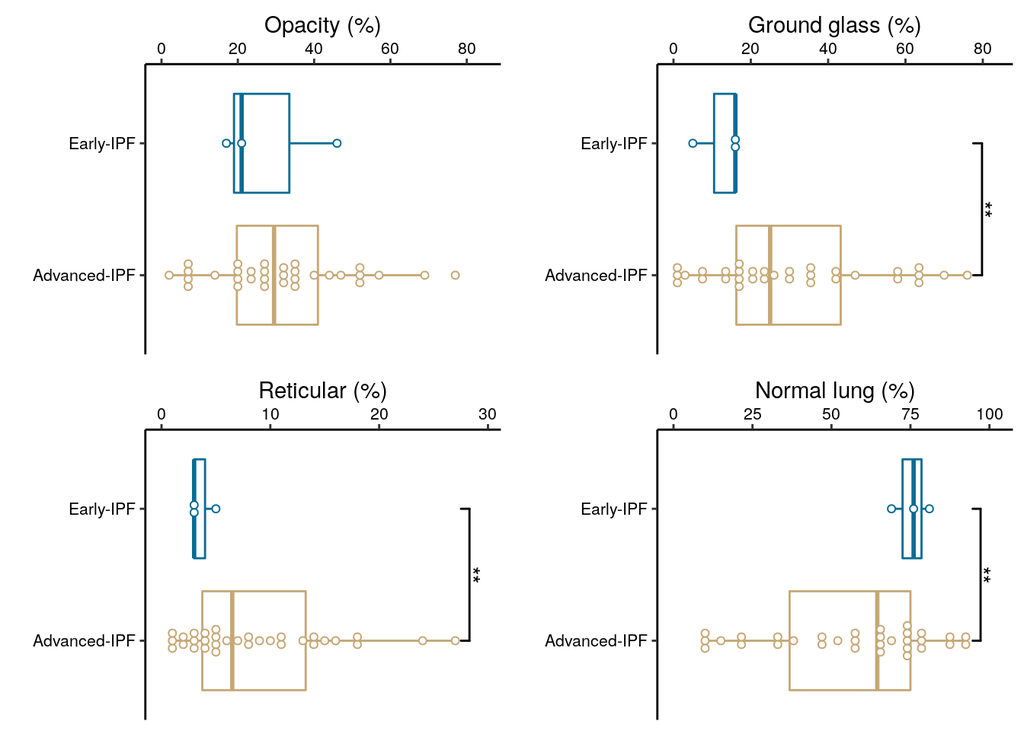

```r
ggpubr::ggarrange(plotlist = plot_list,ncol = 2,nrow = 2)
```

```r
rm(pnt_stage,cols.num,i,test,my_comparisons,p,plot_list)
```

## 3.3 figure S1D

```r
facs_major = readxl::read_xls(paste0(working.dir,"/IPF_manuscript/manuscriptV3/meta_data/230523JTanalysis_backup5.wsp_major_counts.xls"),sheet = "Sheet0")

colnames(facs_major) = c("file","identifier","immune","myeloid","single")

## add stage information
pnt_stage = read.csv(file = paste0(working.dir,"/IPF_manuscript/manuscriptV3/meta_data/20230605_scaledvalue_patient_stages.csv"))

facs_major = merge(facs_major,pnt_stage[,c("identifier","stage")],by.x = "identifier",by.y="identifier")

facs_major$immune_percent = facs_major$immune/facs_major$single
facs_major$myeloid_percent = facs_major$myeloid/facs_major$single
facs_major$nonimmune_percent = (facs_major$single - facs_major$immune) / facs_major$single
facs_major$adaptive_percent = (facs_major$immune - facs_major$myeloid) / facs_major$single

facs_major_tmp = facs_major[facs_major$stage %in% c("Control","Early-IPF","Advanced-IPF"),c("identifier","stage","myeloid_percent","adaptive_percent","nonimmune_percent")] %>%
  tidyr::pivot_longer(cols = c("myeloid_percent","adaptive_percent","nonimmune_percent"),names_to = "Cell",values_to = "value")

facs_major_tmp$stage = factor(facs_major_tmp$stage,levels = c("Control","Early-IPF","Advanced-IPF"))

group_color = c("adaptive_percent" = "#C2AACB",
                "myeloid_percent" = "#8DD3C7",
                "nonimmune_percent" = "#6C79D4")

pdf(file = paste0(ms_dir,"/figs1d_facs_majorcount_",ms_date,".pdf"),paper = "a4",width = 6.5,height = 2)
p = ggplot(facs_major_tmp,aes(x=identifier,y=value,fill=Cell))+
  geom_bar(position = "stack",stat = "identity")+
  # geom_text(position = position_dodge(width = 1),aes(x=stage,y=0))+
  ylab("Frequency")+
  xlab("")+
  facet_grid(~stage,scales = "free_x",space="free_x",switch = "x")+
  scale_fill_manual(values = group_color,name="",labels=c("B/T/NK cell","Myeloid cell","Non-immune cell"))+
  # scale_fill_discrete(name="Cell type",labels=c("B/T/NK cell","Myeloid cell","Non-immune cell"))+
  theme_classic()+theme(axis.text.x = element_blank(),
         axis.ticks.x = element_blank(),
         axis.line = element_blank(),
         axis.text.y = element_text(size = 8,colour = "black"),
         # axis.title.y = element_text(size = 8,colour = "black"),
         axis.title.y = element_text(size = 10,colour = "black"),
         title = element_text(size = 7,colour = "black"),
         plot.title = element_text(hjust=0.5),
         panel.border = element_rect(color = "black",size=0.8,fill = NA),
        strip.background = element_rect(color = "white"),
        legend.text = element_text(size = 6,colour = "black"),
        legend.key.size = unit(0.3,"cm"),
        panel.spacing.x = unit(0.1,"lines"),
        legend.box.margin = margin(-20,-20,-20,-11))
plot(p)
dev.off()
```

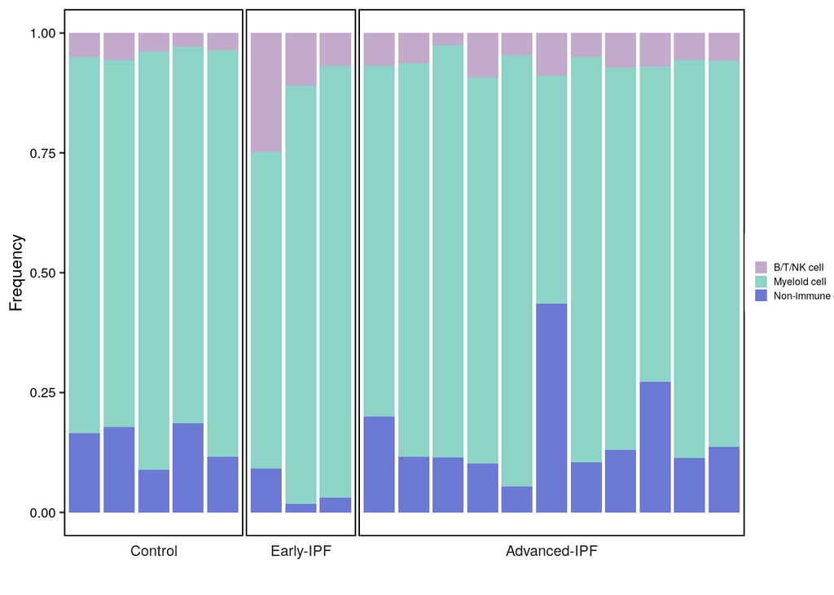

```r
p
```

```r
rm(facs_major,pnt_stage,facs_major_tmp,group_color,p)
```

## 3.4 figure S1E

### 3.4.1 upload facs data

```r
facs_data = readxl::read_xlsx(paste0(working.dir,"/IPF_manuscript/manuscriptV3/meta_data/fig1DE_20230525_v1.xlsx"),sheet = "Sheet1")

facs_data = facs_data[,c("patient","CD169- CD206-","preDC","CD169+ CD206+","DC1","pDC","DC2","Eosinophils","CD16+ Gran","CD16- Gran","DiseaseGroup")]

colnames(facs_data) = c("patient","CD169-CD206-","preDC","CD169+CD206+","DC1","pDC","DC2","Eosinophil","CD16+Granulocyte","CD16-Granulocyte","disease")

## add stage information
pnt_stage = read.csv(file = paste0(working.dir,"/IPF_manuscript/meta_data/20230605_scaledvalue_patient_stages.csv"))

facs_data = merge(facs_data,pnt_stage[,c("identifier","stage")],by.x="patient",by.y="identifier")

rm(pnt_stage)
```

### 3.4.2 per disease

```r
plot_list = list()
# install.packages("ggbreak")

pdf(file = paste0(ms_dir,"/figs1e_facs_",ms_date,".pdf"),paper = "a4",width = 7,height = 3)

cell_type_label = c(expression(CD169^"-"~CD206^"-"),expression(CD169^"+"~CD206^"+"),"Eosinophil",expression(CD16^"+"~Granulocyte),expression(CD16^"-"~Granulocyte),"pDC","DC1","DC2","preDC")
cell_type = c("CD169-CD206-","CD169+CD206+","Eosinophil","CD16+Granulocyte","CD16-Granulocyte","pDC","DC1","DC2","preDC")


for(i in c(1:length(cell_type))){

  tmp_data = facs_data[facs_data$stage %in% c("Control","Early-IPF","Advanced-IPF"),c("patient",cell_type[i],"stage")]
  colnames(tmp_data) = c("patient","para","Stage")

  tmp_data$Stage = factor(tmp_data$Stage,levels = c("Control","Early-IPF","Advanced-IPF"))

  if(i == 3| i == 7){
    my_comparisons <- list(
  # c("Control","Early-IPF"),
  c("Control","Advanced-IPF")
  # c("Early-IPF","Advanced-IPF")
                        )
  }else{
    my_comparisons <- list(
  # c("Control","Early-IPF"),
  # c("Control","Advanced-IPF"),
  # c("Early-IPF","Advanced-IPF")
                        )
  }

  if(i==1){
    p =  tmp_data  %>%
  ggplot(.,aes(x=Stage,y=as.numeric(para),color=Stage))+
  geom_boxplot(outlier.shape=NA,outlier.size=6)+
  geom_dotplot(aes(y=as.numeric(para)),fill="white",binaxis='y', stackdir='center', dotsize=0.9)+
  # ggpubr::stat_compare_means(aes(label = ..p.format..),comparisons = my_comparisons,method = "t.test",hide.ns = TRUE)+
  # ggpubr::stat_compare_means(aes(label = ..p.signif..),comparisons = my_comparisons,method = "t.test",hide.ns = TRUE,bracket.size = 0.5,vjust = 0.6)+
  scale_color_manual(values = stage_color)+
  theme_classic()+
  scale_y_continuous(trans = "log10")+
  # ylim(c(0,max(tmp_data$para)*1.1 ))+
  # ggbreak::scale_y_break(c(2.5,12))+
  # ylab(label = paste0("Out of all cells (%)"))+
  labs(title = cell_type_label[i])+
  xlab("")+
  # coord_flip()+
   theme(axis.text.x = element_blank(),
         axis.ticks.x = element_blank(),
         axis.line = element_blank(),
         axis.text.y = element_text(size = 8,colour = "black"),
         # axis.title.y = element_text(size = 8,colour = "black"),
         axis.title.y = element_blank(),
         title = element_text(size = 7,colour = "black"),
         plot.title = element_text(hjust=0.5),
         panel.border = element_rect(color = "black",size=0.8,fill = NA),
         legend.position = "NULL")
  }else{
    p =  tmp_data  %>%
  ggplot(.,aes(x=Stage,y=as.numeric(para),color=Stage))+
  geom_boxplot(outlier.shape=NA,outlier.size=6)+
  geom_dotplot(aes(y=as.numeric(para)),fill="white",binaxis='y', stackdir='center', dotsize=0.9)+
  # ggpubr::stat_compare_means(aes(label = ..p.format..),comparisons = my_comparisons,method = "t.test",hide.ns = TRUE)+
  ggpubr::stat_compare_means(aes(label = ..p.signif..),comparisons = my_comparisons,method = "t.test",hide.ns = TRUE,bracket.size = 0.5,vjust = 0.6)+
  scale_color_manual(values = stage_color)+
  theme_classic()+
  ylim(c(0,max(tmp_data$para)*1.1 ))+
  # scale_y_continuous(position = "right")+
  # ylab(label = paste0("Out of all cells (%)"))+
  labs(title = cell_type_label[i])+
  xlab("")+
  # coord_flip()+
   theme(axis.text.x = element_blank(),
         axis.ticks.x = element_blank(),
         axis.line = element_blank(),
         axis.text.y = element_text(size = 8,colour = "black"),
         # axis.title.y = element_text(size = 8,colour = "black"),
         axis.title.y = element_blank(),
         title = element_text(size = 7,colour = "black"),
         plot.title = element_text(hjust=0.5),
         panel.border = element_rect(color = "black",size=0.8,fill = NA),
         legend.position = "NULL")
  }


plot_list[[cell_type[i]]] = p
}

p = tmp_data  %>%
  ggplot(.,aes(x=Stage,y=as.numeric(para),color=Stage))+
  geom_boxplot(outlier.shape=NA,outlier.size=4)+
  scale_color_manual(values = stage_color)+
   theme(axis.text.x = element_blank(),
         axis.text.y = element_text(size = 8,colour = "black"),
         axis.title.y = element_text(size = 8,colour = "black"),
         title = element_text(size = 6,colour = "black"),
         plot.title = element_text(hjust=0.5),
         panel.border = element_rect(color = "black",size=1,fill = NA),
         legend.text = element_text(size = 6,colour = "black"))

plot_list[["legend"]] = cowplot::get_legend(p) %>% cowplot::plot_grid()

p = ggpubr::ggarrange(plotlist = plot_list,ncol = 5,nrow = 2)
ggpubr::annotate_figure(p,left = textGrob(expression("%"~of~Lin^"-"~CD45^"+"~cells), rot = 90, vjust=1,gp=gpar(cex=0.8)))

dev.off()
```

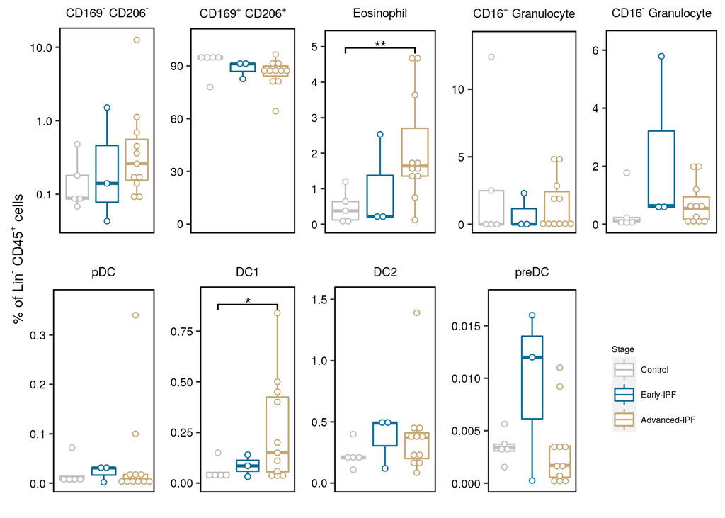

```r
ggpubr::annotate_figure(p,left = textGrob(expression("%"~of~Lin^"-"~CD45^"+"~cells), rot = 90, vjust=1,gp=gpar(cex=0.8)))
```

```r
rm(plot_list,i,p,tmp_data,my_comparisons,cell_type,cell_type_label)
```

R version 4.1.3 (2022-03-10) Platform: x86_64-pc-linux-gnu (64-bit) Running under: Ubuntu 20.04.4 LTS

Matrix products: default BLAS/LAPACK: /usr/lib/x86_64-linux-gnu/openblas-pthread/libopenblasp-r0.3.8.so

locale: [1] C

attached base packages: [1] grid stats graphics grDevices utils datasets methods  
[8] base

other attached packages: [1] Amelia_1.8.0 Rcpp_1.0.8.3 ggplot2_3.3.5  
[4] ComplexHeatmap_2.10.0 magrittr_2.0.3

loaded via a namespace (and not attached): [1] sass_0.4.1 tidyr_1.2.0 jsonlite_1.8.0  
[4] foreach_1.5.2 carData_3.0-5 tmvnsim_1.0-2  
[7] bslib_0.3.1 assertthat_0.2.1 highr_0.9  
[10] stats4_4.1.3 cellranger_1.1.0 yaml_2.3.5  
[13] corrplot_0.92 pillar_1.7.0 backports_1.4.1  
[16] lattice_0.20-45 glue_1.6.2 digest_0.6.29  
[19] RColorBrewer_1.1-3 ggsignif_0.6.3 colorspace_2.0-3  
[22] cowplot_1.1.1 htmltools_0.5.2 psych_2.3.6  
[25] pkgconfig_2.0.3 GetoptLong_1.0.5 broom_0.8.0  
[28] magick_2.7.3 purrr_0.3.4 scales_1.1.1  
[31] tibble_3.1.6 farver_2.1.0 generics_0.1.2  
[34] IRanges_2.28.0 car_3.0-12 ellipsis_0.3.2  
[37] ggpubr_0.4.0 withr_2.5.0 BiocGenerics_0.40.0 [40] cli_3.2.0 mnormt_2.0.2 crayon_1.5.1  
[43] readxl_1.4.0 evaluate_0.15 fansi_1.0.3  
[46] doParallel_1.0.17 nlme_3.1-155 rstatix_0.7.0  
[49] foreign_0.8-82 tools_4.1.3 GlobalOptions_0.1.2 [52] lifecycle_1.0.1 matrixStats_0.61.0 stringr_1.4.0  
[55] S4Vectors_0.32.4 munsell_0.5.0 cluster_2.1.2  
[58] compiler_4.1.3 jquerylib_0.1.4 rlang_1.0.2  
[61] iterators_1.0.14 rstudioapi_0.13 rjson_0.2.21  
[64] circlize_0.4.14 labeling_0.4.2 rmarkdown_2.14  
[67] gtable_0.3.0 codetools_0.2-18 abind_1.4-5  
[70] DBI_1.1.2 R6_2.5.1 gridExtra_2.3  
[73] knitr_1.37 dplyr_1.0.8 fastmap_1.1.0  
[76] utf8_1.2.2 clue_0.3-60 shape_1.4.6  
[79] stringi_1.7.6 parallel_4.1.3 vctrs_0.4.0  
[82] png_0.1-7 tidyselect_1.1.2 xfun_0.29